# Week 2, Class 3

Working with Real Data

Sean Westwood

## In Today’s Class

- Load and explore real political datasets using tidyverse
- Master essential data manipulation: `filter()`, `select()`, `arrange()`
- Use the pipe operator `%>%` to chain operations
- Handle missing values (NA) properly

# Loading Real Political Data

## The DW-NOMINATE Dataset

**What is DW-NOMINATE?**

- **Dynamic Weighted NOMINATE**: Measures of ideological positions
- **Created by**: Keith Poole and Howard Rosenthal
- **Covers**: Every member of Congress from 1789 to present
- **Scale**: -1 (liberal) to +1 (conservative)

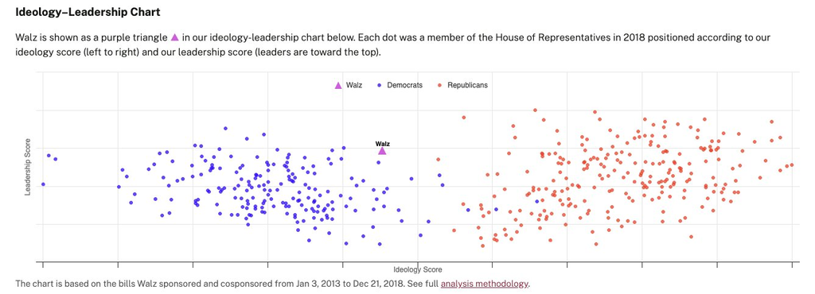

## Loading the Data

```r
library(tidyverse)

# Load DW-NOMINATE data for all members of Congress
congress <- read_csv("../../data/HSall_members.csv")

# Quick look at the structure
glimpse(congress)
```

```
Rows: 51,044
Columns: 22
$ congress                      <dbl> 1, 1, 1, 1, 1, 1, 1, 1, 1, 1, 1, 1, 1, 1…
$ chamber                       <chr> "President", "House", "House", "House", …
$ icpsr                         <dbl> 99869, 379, 4854, 6071, 1538, 2010, 3430…
$ state_icpsr                   <dbl> 99, 44, 44, 44, 52, 52, 52, 52, 52, 52, …
$ district_code                 <dbl> 0, 2, 1, 3, 6, 3, 5, 2, 4, 1, 1, 3, 2, 8…
$ state_abbrev                  <chr> "USA", "GA", "GA", "GA", "MD", "MD", "MD…
$ party_code                    <chr> "5000", "4000", "4000", "4000", "5000", …
$ occupancy                     <dbl> NA, 0, 0, 0, 0, 0, 0, 0, 0, 0, 0, 0, 0, …
$ last_means                    <dbl> NA, 1, 1, 1, 1, 1, 1, 1, 1, 1, 1, 1, 1, …
$ bioname                       <chr> "WASHINGTON, George", "BALDWIN, Abraham"…
$ bioguide_id                   <chr> NA, "B000084", "J000017", "M000234", "C0…
$ born                          <dbl> NA, 1754, 1757, 1739, 1730, 1755, 1756, …
$ died                          <dbl> NA, 1807, 1806, 1812, 1796, 1815, 1815, …
$ nominate_dim1                 <dbl> NA, -0.165, -0.320, -0.428, 0.116, -0.08…
$ nominate_dim2                 <dbl> NA, -0.373, -0.181, -0.317, -0.740, -0.3…
$ nominate_log_likelihood       <dbl> NA, -28.55029, -24.89986, -12.62728, -23…
$ nominate_geo_mean_probability <dbl> NA, 0.758, 0.776, 0.880, 0.783, 0.788, 0…
$ nominate_number_of_votes      <dbl> NA, 103, 98, 99, 96, 92, 94, 106, 103, 9…
$ nominate_number_of_errors     <dbl> NA, 12, 9, 2, 11, 13, 10, 34, 30, 20, 10…
$ conditional                   <lgl> NA, NA, NA, NA, NA, NA, NA, NA, NA, NA, …
$ nokken_poole_dim1             <dbl> NA, -0.429, -0.559, -0.413, 0.114, -0.09…
$ nokken_poole_dim2             <dbl> NA, -0.817, -0.052, -0.232, -0.779, -0.4…
```

# Data Manipulation with Tidyverse

## What is Tidyverse (again)?

**The tidyverse** is a collection of R packages designed for data science that share a common philosophy and grammar.

**Why use tidyverse over base R?**

- **Human-readable code** that reads like sentences
- **Better error messages**: More helpful when things go wrong

## Tidyverse Philosophy: Verbs

**Tidyverse uses “verbs” - functions that describe what they do:**

- `filter()` - **keep** rows that match conditions
- `select()` - **choose** specific columns
- `arrange()` - **sort** rows by values

**Think of it like giving instructions to a research assistant:**

“Filter the data to show only Democrats, then select their names and ideology scores, then arrange by most liberal first”

**Why this matters**: Instead of remembering complex syntax, you can think in terms of what you want to accomplish.

## The `filter()` Function

**Purpose**: Select specific rows based on conditions

**Think of `filter()` as asking**: “Which observations meet my criteria?”

**Example**: Filter for Democrats only

```r
# Filter for Democrats only
democrats <- congress %>%
  filter(party_code == "Democrat")

# How many Democrats?
nrow(democrats)
```

```
[1] 23690
```

**What happened here:**

1. We took the `congress` data frame
2. We kept only rows where `party_code` equals “Democrat”
3. We saved the result as `democrats`
4. We counted how many rows remain using `nrow()`

## Multiple Conditions in filter()

**Representatives from the 110th Congress and later:**

```r
# Multiple conditions - focus on modern Congress members
modern_house <- congress %>%
  filter(chamber == "House",
         congress >= 110,
         party_code %in% c("Democrat", "Republican"))

head(modern_house)
```

```
# A tibble: 6 × 22
  congress chamber icpsr state_icpsr district_code state_abbrev party_code
     <dbl> <chr>   <dbl>       <dbl>         <dbl> <chr>        <chr>
1      110 House   20300          41             1 AL           Republican
2      110 House   20301          41             3 AL           Republican
3      110 House   20302          41             7 AL           Democrat
4      110 House   29100          41             5 AL           Democrat
5      110 House   29300          41             2 AL           Republican
6      110 House   29301          41             6 AL           Republican
# ℹ 15 more variables: occupancy <dbl>, last_means <dbl>, bioname <chr>,
#   bioguide_id <chr>, born <dbl>, died <dbl>, nominate_dim1 <dbl>,
#   nominate_dim2 <dbl>, nominate_log_likelihood <dbl>,
#   nominate_geo_mean_probability <dbl>, nominate_number_of_votes <dbl>,
#   nominate_number_of_errors <dbl>, conditional <lgl>,
#   nokken_poole_dim1 <dbl>, nokken_poole_dim2 <dbl>
```

**Understanding multiple conditions:**

- **Commas mean “AND”**: All conditions must be true
- `chamber == "House"` - Must be House member
- `congress >= 110` - Must be from 110th Congress or later
- `party_code %in% c("Democrat", "Republican")` - Must be major party

**The `%in%` operator**: Checks if a value appears in a list of options

## Advanced Filtering

**Senators from Large States in the 118th Congress:**

```r
# Filter for senators from CA, TX, or FL in the 110th Congress
big_state_senators <- congress %>%
  filter(chamber == "Senate",
         state_abbrev %in% c("CA", "TX", "FL"),
         congress == 118)

head(big_state_senators)
```

```
# A tibble: 6 × 22
  congress chamber icpsr state_icpsr district_code state_abbrev party_code
     <dbl> <chr>   <dbl>       <dbl>         <dbl> <chr>        <chr>
1      118 Senate  20104          71             0 CA           Democrat
2      118 Senate  42104          71             0 CA           Democrat
3      118 Senate  42305          71             0 CA           Democrat
4      118 Senate  49300          71             0 CA           Democrat
5      118 Senate  41102          43             0 FL           Republican
6      118 Senate  41903          43             0 FL           Republican
# ℹ 15 more variables: occupancy <dbl>, last_means <dbl>, bioname <chr>,
#   bioguide_id <chr>, born <dbl>, died <dbl>, nominate_dim1 <dbl>,
#   nominate_dim2 <dbl>, nominate_log_likelihood <dbl>,
#   nominate_geo_mean_probability <dbl>, nominate_number_of_votes <dbl>,
#   nominate_number_of_errors <dbl>, conditional <lgl>,
#   nokken_poole_dim1 <dbl>, nokken_poole_dim2 <dbl>
```

## The `select()` Function

**Purpose**: Choose specific columns you want to work with

**Think of `select()` as asking**: “Which variables do I need for my analysis?”

**Basic selection:**

```r
# Select key variables for analysis
key_vars <- congress %>%
  select(bioname, party_code, state_abbrev, chamber, nominate_dim1)

head(key_vars)
```

```
# A tibble: 6 × 5
  bioname            party_code state_abbrev chamber   nominate_dim1
  <chr>              <chr>      <chr>        <chr>             <dbl>
1 WASHINGTON, George 5000       USA          President        NA
2 BALDWIN, Abraham   4000       GA           House            -0.165
3 JACKSON, James     4000       GA           House            -0.32
4 MATHEWS, George    4000       GA           House            -0.428
5 CARROLL, Daniel    5000       MD           House             0.116
6 CONTEE, Benjamin   4000       MD           House            -0.08
```

**Why select specific columns:**

- **Focus**: Work with only the variables you need
- **Clarity**: Easier to see what you’re working with
- **Performance**: Smaller datasets work faster
- **Organization**: Keeps your analysis clean and focused

## Advanced `select()` Options

**Helper functions make selection easier:**

```r
# Select multiple columns at once
congress %>%
  select(bioname, party_code, chamber, everything()) %>%
  head()
```

```
# A tibble: 6 × 22
  bioname            party_code chamber congress icpsr state_icpsr district_code
  <chr>              <chr>      <chr>      <dbl> <dbl>       <dbl>         <dbl>
1 WASHINGTON, George 5000       Presid…        1 99869          99             0
2 BALDWIN, Abraham   4000       House          1   379          44             2
3 JACKSON, James     4000       House          1  4854          44             1
4 MATHEWS, George    4000       House          1  6071          44             3
5 CARROLL, Daniel    5000       House          1  1538          52             6
6 CONTEE, Benjamin   4000       House          1  2010          52             3
# ℹ 15 more variables: state_abbrev <chr>, occupancy <dbl>, last_means <dbl>,
#   bioguide_id <chr>, born <dbl>, died <dbl>, nominate_dim1 <dbl>,
#   nominate_dim2 <dbl>, nominate_log_likelihood <dbl>,
#   nominate_geo_mean_probability <dbl>, nominate_number_of_votes <dbl>,
#   nominate_number_of_errors <dbl>, conditional <lgl>,
#   nokken_poole_dim1 <dbl>, nokken_poole_dim2 <dbl>
```

**Useful `select()` helpers:**

- `everything()` - All remaining columns
- `starts_with("nom")` - Columns starting with “nom”
- `ends_with("_code")` - Columns ending with “_code”
- `contains("state")` - Columns containing “state”

**Pro tip**: You can also use `select()` to reorder columns by listing them in your preferred order.

## The `arrange()` Function

**Purpose**: Sort data by one or more variables

**Think of `arrange()` as asking**: “In what order should I view these observations?”

**Example**: Sort by ideology (most liberal to most conservative)

```r
# Sort by DW-NOMINATE score (most liberal to most conservative)
congress %>%
  arrange(nominate_dim1) %>%
  head()
```

```
# A tibble: 6 × 22
  congress chamber icpsr state_icpsr district_code state_abbrev party_code
     <dbl> <chr>   <dbl>       <dbl>         <dbl> <chr>        <chr>
1       44 House    3131          13             7 NY           Democrat
2       80 House    4831          13            24 NY           522
3       63 House    2891          45             5 LA           Democrat
4       79 Senate   9210          63             0 ID           Democrat
5       80 Senate   9210          63             0 ID           Democrat
6       81 Senate   9210          63             0 ID           Democrat
# ℹ 15 more variables: occupancy <dbl>, last_means <dbl>, bioname <chr>,
#   bioguide_id <chr>, born <dbl>, died <dbl>, nominate_dim1 <dbl>,
#   nominate_dim2 <dbl>, nominate_log_likelihood <dbl>,
#   nominate_geo_mean_probability <dbl>, nominate_number_of_votes <dbl>,
#   nominate_number_of_errors <dbl>, conditional <lgl>,
#   nokken_poole_dim1 <dbl>, nokken_poole_dim2 <dbl>
```

## Arranging in Descending Order

**Use `desc()` to sort from highest to lowest:**

```r
# Sort highest to lowest using desc() - most conservative first
congress %>%
  arrange(desc(nominate_dim1)) %>%
  head()
```

```
# A tibble: 6 × 22
  congress chamber icpsr state_icpsr district_code state_abbrev party_code
     <dbl> <chr>   <dbl>       <dbl>         <dbl> <chr>        <chr>
1       70 Senate   9862          62             0 CO           Republican
2       71 Senate   9862          62             0 CO           Republican
3       72 Senate   9862          62             0 CO           Republican
4        8 House    3840          13            15 NY           1
5        3 House    9161          13            10 NY           5000
6        1 Senate   4998           1             0 CT           5000
# ℹ 15 more variables: occupancy <dbl>, last_means <dbl>, bioname <chr>,
#   bioguide_id <chr>, born <dbl>, died <dbl>, nominate_dim1 <dbl>,
#   nominate_dim2 <dbl>, nominate_log_likelihood <dbl>,
#   nominate_geo_mean_probability <dbl>, nominate_number_of_votes <dbl>,
#   nominate_number_of_errors <dbl>, conditional <lgl>,
#   nokken_poole_dim1 <dbl>, nokken_poole_dim2 <dbl>
```

**Understanding `desc()`:**

- **Default**: `arrange()` sorts from low to high (ascending)
- **With `desc()`**: Sorts from high to low (descending)
- **Remember**: `desc(nominate_dim1)` shows most conservative first

**Multiple sorting variables**: You can sort by multiple columns:

```r
arrange(state_abbrev, desc(nominate_dim1))  # By state, then by ideology
```

## The Pipe Operator: %>%

**The pipe (`%>%`) connects verbs together and makes code more readable.**

**How to read pipes**: Read `%>%` as “then”

“Filter the data to show only Democrats, then select their names and ideology scores, then arrange by most liberal first”

**This task in Tidyverse:**

```r
# Use pipes (reads left to right):
data %>%
  filter(condition) %>%    # Step 1: Filter the data, THEN
  select(columns) %>%      # Step 2: Select columns, THEN
  arrange(variable) %>%    # Step 3: Arrange rows, THEN
  head()                   # Step 4: Show the first few
```

**Why pipes are helpful:**

- **Sequential logic**: Operations flow from left to right
- **No intermediate objects**: Don’t need to save results at each step
- **Readable**: Code reads like instructions in English

## Why This Matters for Political Science

- **Reproducible research**: Other scholars can easily understand and verify your analysis
- **Collaborative work**: Team members can read and modify each other’s code
- **Teaching and learning**: Students can follow the logical flow of analysis
- **AI assistance**: Clear, well-structured code is easier for AI to help debug and extend

**Example**: “Show me the most conservative Republicans from Texas in recent Congresses” becomes a clear sequence of filter → select → arrange operations

# Handling Missing Data

## Why Missing Data Is Problematic

**R cannot perform calculations when data contains missing values.**

**Let’s see what happens:**

```r
# This will return NA!
example_data <- c(10, 5, NA)
mean(example_data)
```

```
[1] NA
```

**The problem**: R doesn’t know what to do with missing values. Should it:

- Ignore the missing value?
- Treat it as zero?
- Stop the calculation entirely?

**R’s solution**: Return `NA` to force you to make an explicit decision about how to handle missing data.

## Understanding NA Values

**NA** means “Not Available” - missing data that we need to handle carefully.

**Option 1: Use `na.rm = TRUE` in calculations**

```r
# Create a data frame with missing values
example_df <- tibble(values = c(10, 5, NA, 8, NA, 12))

# Option 1: Use na.rm in summarise
example_df %>%
  summarise(mean_with_na_rm = mean(values, na.rm = TRUE))
```

```
# A tibble: 1 × 1
  mean_with_na_rm
            <dbl>
1            8.75
```

**What `na.rm = TRUE` does**: “Remove NAs before calculating”

## Why this matters

**Why this matters**: In political science, missing data is common and important:

- **Survey non-response**: When people don’t answer certain questions in polls or surveys
- **Incomplete voting records**: When a legislator doesn’t vote on a particular bill
- **Historical data gaps**: When data is missing for certain time periods
- **Measurement challenges**: When a variable is not measured for some observations

## The `is.na()` Function

We need to be able to check for missing values and handle them appropriately.

**These approaches DON’T work:**

```r
example_df %>%
  mutate(
    wrong_1 = (values == NA),      # Returns NA, not TRUE/FALSE!
    wrong_2 = (values == "NA")     # Checks for text "NA", not missing values
  )
```

**Why they fail:**

- `== NA` returns `NA` because “is unknown equal to unknown?” is unknown
- `== "NA"` looks for the text string “NA”, not actual missing values

**Key principle**: You cannot use `==` to check for missing values because `NA` is not equal to anything, not even itself!

## The `is.na()` Function: Correct Approach

**`is.na()` is designed specifically to detect missing values:**

```r
# This is the correct way to check for missing values
is.na(example_df$values)
```

```
[1] FALSE FALSE  TRUE FALSE  TRUE FALSE
```

**What `is.na()` returns:**

- `TRUE` if the value is missing (NA)
- `FALSE` if the value is not missing

## Using `is.na()`

- `filter(is.na(variable))` - Keep only missing values
- `filter(!is.na(variable))` - Remove missing values
- `sum(is.na(variable))` - Count missing values

## The “NOT” Operator: !

**The `!` operator means “NOT” - it flips TRUE/FALSE values:**

**Code**:

```r
# Check which values are missing
example_df %>%
  filter(is.na(values))
```

**Results**:

```
# A tibble: 2 × 1
  values
   <dbl>
1     NA
2     NA
```

```r
# Use ! to flip the result - which values are NOT missing
example_df %>%
  filter(!is.na(values))
```

```
# A tibble: 4 × 1
  values
   <dbl>
1     10
2      5
3      8
4     12
```

- `!TRUE` becomes `FALSE`
- `!FALSE` becomes `TRUE`
- `!is.na(values)` means “values that are NOT missing”

**Key concept**: `!is.na(values)` means “keep rows where values are NOT missing”

## Another Way to Handle Missing Values

**Remove missing values first, then calculate the mean**

```r
example_df %>%
  filter(!is.na(values)) %>%
  summarise(mean_clean = mean(values))
```

```
# A tibble: 1 × 1
  mean_clean
       <dbl>
1       8.75
```

**What this approach does:**

1. `filter(!is.na(values))` - Remove all rows with missing values
2. `mean(values)` - Calculate mean on clean data (no `na.rm` needed)

**When to use this**: When you want to work only with complete observations

## Understand How Many Missing Values Are in the Data

**We need to know how much data is missing before we can decide how to handle it.**

- If we have a lot of missing values, we may need to reconsider our analysis.
- If we have a just a few missing values, we can just remove them.

```r
example_df %>%
  summarise(
    total_values = n(),
    missing_count = sum(is.na(values)),
    complete_count = sum(!is.na(values))
  )
```

```
# A tibble: 1 × 3
  total_values missing_count complete_count
         <int>         <int>          <int>
1            6             2              4
```

**Understanding the counting:**

- `n()` - Total number of rows
- `sum(is.na(values))` - Count TRUE values (missing)
- `sum(!is.na(values))` - Count TRUE values (not missing)

## An AI Prompt

> “I have a dataset called `congress` and I want to understand how much missing data there is in the `nominate_dim1` variable. Please write R code that will count the total number of observations, count how many values are missing in the `nominate_dim1` column, calculate the percentage of missing data, and show me summary statistics for both the complete and missing cases. Use tidyverse. Explain each step.”

## Using `na.rm = TRUE` in Calculations

We need to be able to handle missing values in calculations, and we need to explicitly tell R how to handle them.

**For calculations like `mean()`, `sum()`, and `sd()`, use `na.rm = TRUE` to ignore missing values:**

**Without `na.rm = TRUE`:**

```r
# This will return NA because of missing values
mean(congress$nominate_dim1)
```

```
[1] NA
```

**With `na.rm = TRUE`:**

```r
# Use na.rm = TRUE to ignore missing values
mean(congress$nominate_dim1, na.rm = TRUE)
```

```
[1] 0.007268118
```

**`na.rm = TRUE` means**: “Remove NA values before calculating”

**Important**: This doesn’t change your original data - it only affects the calculation

## Other Functions That Support `na.rm`

**Many statistical functions support `na.rm = TRUE`:**

```r
median(congress$nominate_dim1, na.rm = TRUE)  # Middle value
```

```
[1] -0.04
```

```r
min(congress$nominate_dim1, na.rm = TRUE)     # Minimum value
```

```
[1] -1
```

**Remember**: Without `na.rm = TRUE`, all of these would return `NA` if any values are missing.

**Best practice**: Always check for missing values before doing analysis, then decide how to handle them.